# PR11 - ggplot

## 1.2. ggplot2로 barplot 그리기

- 실린더 수에 대한 barplot을 그림
- 막대는 기어의 개수에 따라 서로 다른 facet에 출력
- facet이란 독립된 subplot이 그려지는 패널구조를 의미
- 결과값을 보면 3개의 subplot이 있는 것을 확인 할 수 있음
- 산점도 색상옵션으로 colour인수사용, barplot은 색상옵션으로 fill인수 사용

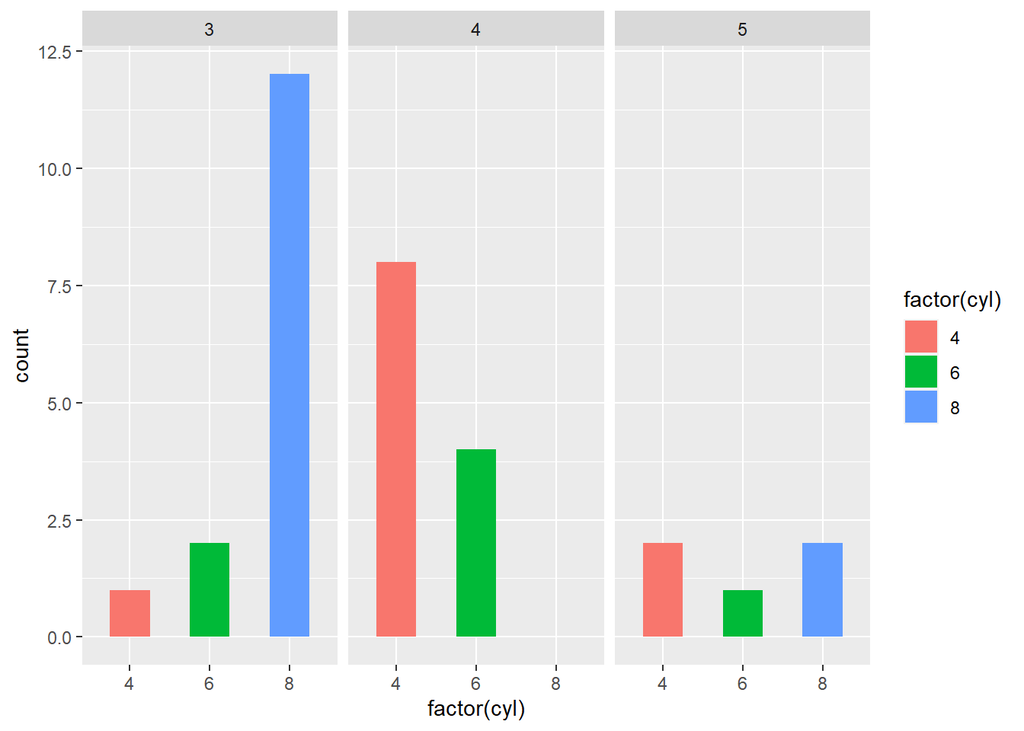

```r
b <-ggplot(data=mtcars,aes(x=factor(cyl),fill=factor(cyl)))
b <- b + geom_bar(width=.5) #bar의 넓이를 정의
b <- b + facet_grid(.~gear) #기어 개수에 따른 facet 분할
b
```

## 1.3. ggplot Layer

- ggplot은 Layer를 쌓아가는 방식으로 사용
- ggplot = layers + scales + coordinate system
- layers = data + mapping + geom + stat + position
- scales와 coordinate system은 그림을 그릴 캔버스의 개념
- layers가 실제 그리는 그림
- data, mapping, geom 등등으로 하나씩 중첩해가면서 plot을 그림
- geom의 요소 또한 중첩 가능

```r
p <- ggplot(mtcars,aes(wt,mpg))
p <- p+geom_point() ; p
```

[output not shown]

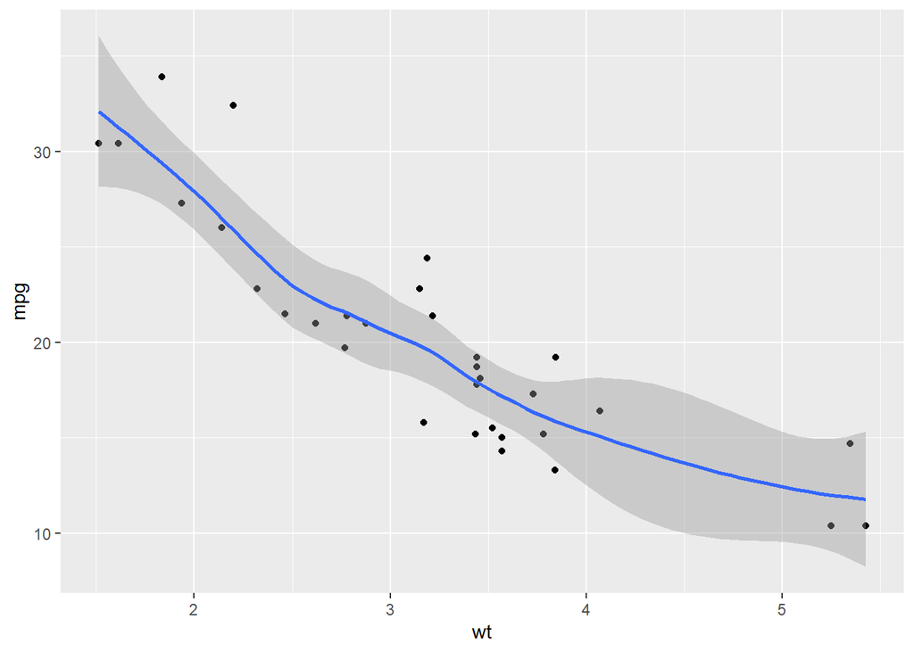

```r
p <- p+geom_smooth(method="loess") #라인 그래프 smooth 그리기
p
```

```r
summary(p)
```

```
## data: mpg, cyl, disp, hp, drat, wt, qsec, vs, am, gear, carb [32x11]
## mapping:  x = ~wt, y = ~mpg
## faceting: <ggproto object: Class FacetNull, Facet, gg>
##     compute_layout: function
##     draw_back: function
##     draw_front: function
##     draw_labels: function
##     draw_panels: function
##     finish_data: function
##     init_scales: function
##     map_data: function
##     params: list
##     setup_data: function
##     setup_params: function
##     shrink: TRUE
##     train_scales: function
##     vars: function
##     super:  <ggproto object: Class FacetNull, Facet, gg>
## -----------------------------------
## geom_point: na.rm = FALSE
## stat_identity: na.rm = FALSE
## position_identity
##
## geom_smooth: na.rm = FALSE, orientation = NA, se = TRUE, flipped_aes = FALSE
## stat_smooth: na.rm = FALSE, orientation = NA, se = TRUE, method = loess
## position_identity
```

- 동일한 결과를 다르게 표현

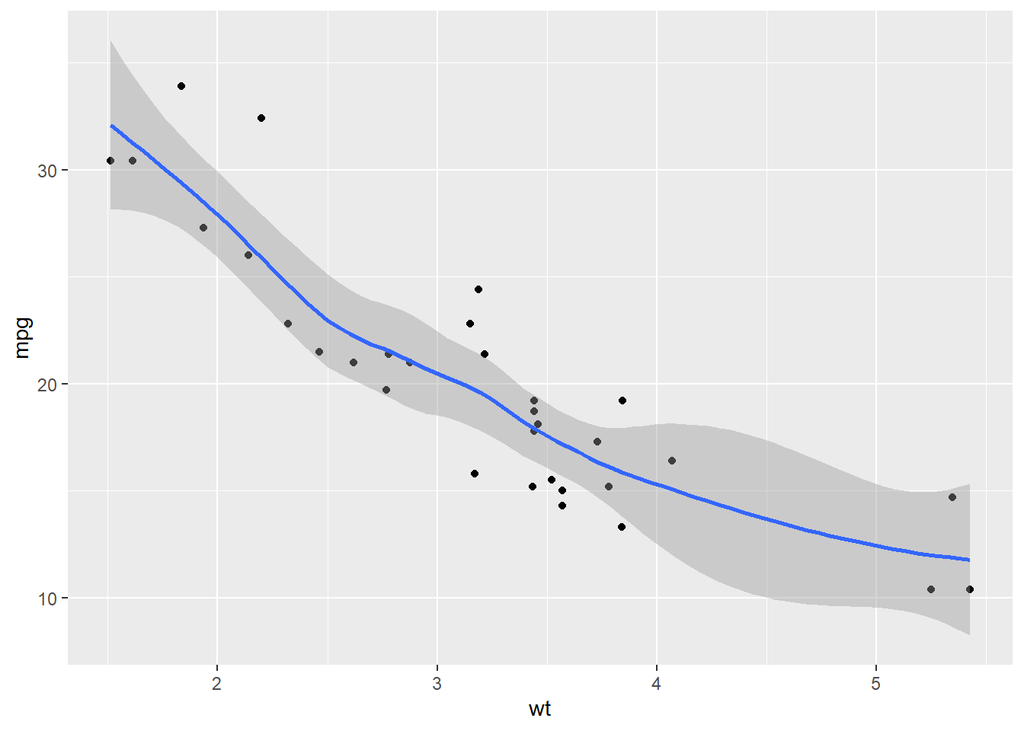

```r
p <- ggplot(mtcars,aes(wt,mpg)) +
  geom_point() +
  geom_smooth(method="loess") #라인 그래프 smooth 그리기
p
```

## 1.4. ggplot 요약

# 2. ggplot2 함수군

## 2.1. Plot creating 함수군

- 기초 플롯인 ggplot 클래스 객체를 생성
- 가장 많이 사용하는 함수는 ggplot()과 qplot()
  - ggplot() 함수는 dataframe 객체로 플롯을 그릴 떄 사용
  - qplot() 함수는 각 변수가 독립적인 객체로 존재할 때 사용

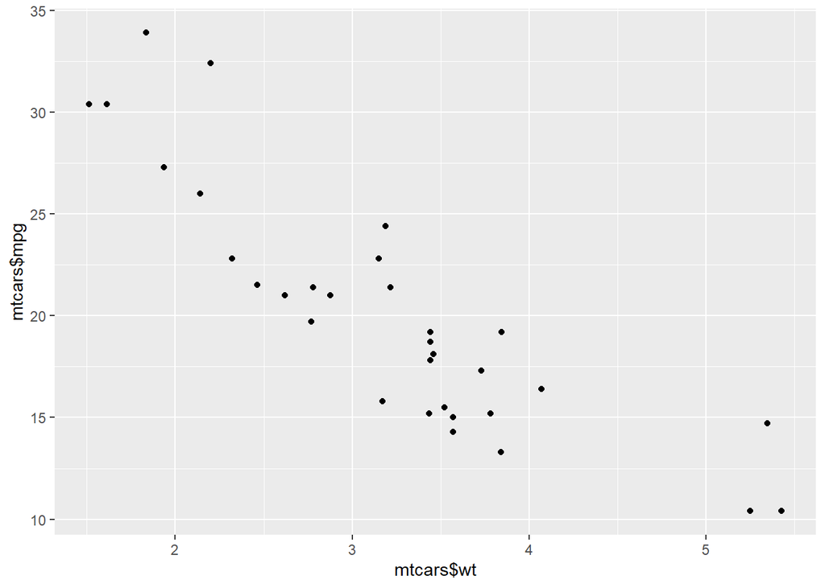

```r
qplot(mtcars$wt,mtcars$mpg)
```

```r
ggplot(mtcars,aes(wt,mpg)) + geom_point()
```

[output not shown]

- qplot() 함수는 geo을 지정하지 않을 경우 point로 적용됨
- ggplot은 모든 그래픽 인수들을 구체적으로 지정해야함

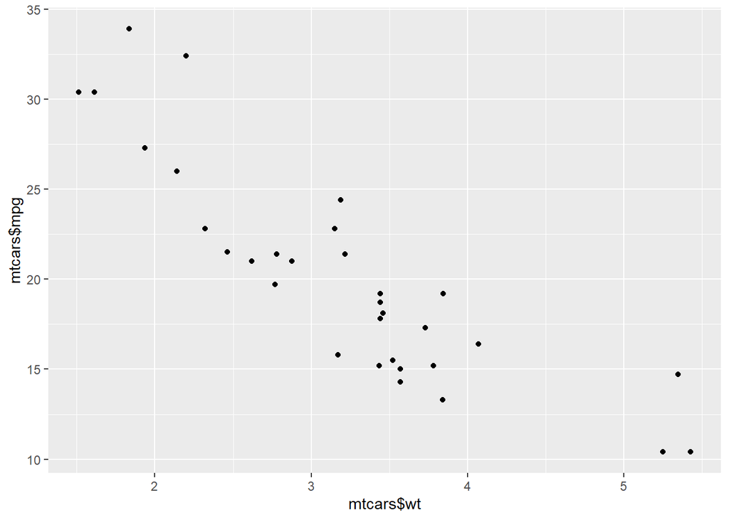

```r
qplot(mtcars$wt, mtcars$mpg, geom="point")
```

```r
qplot(wt,mpg, data=mtcars, geom="point") #그래프는 위와 동일함
```

## 2.2. Geoms 함수군

- geometric 요소를 지정하기 위한 함수군
- 선,점,막대,박스,파이 등을 생각하면 됨

### 2.2.1. geom_point() 산점도

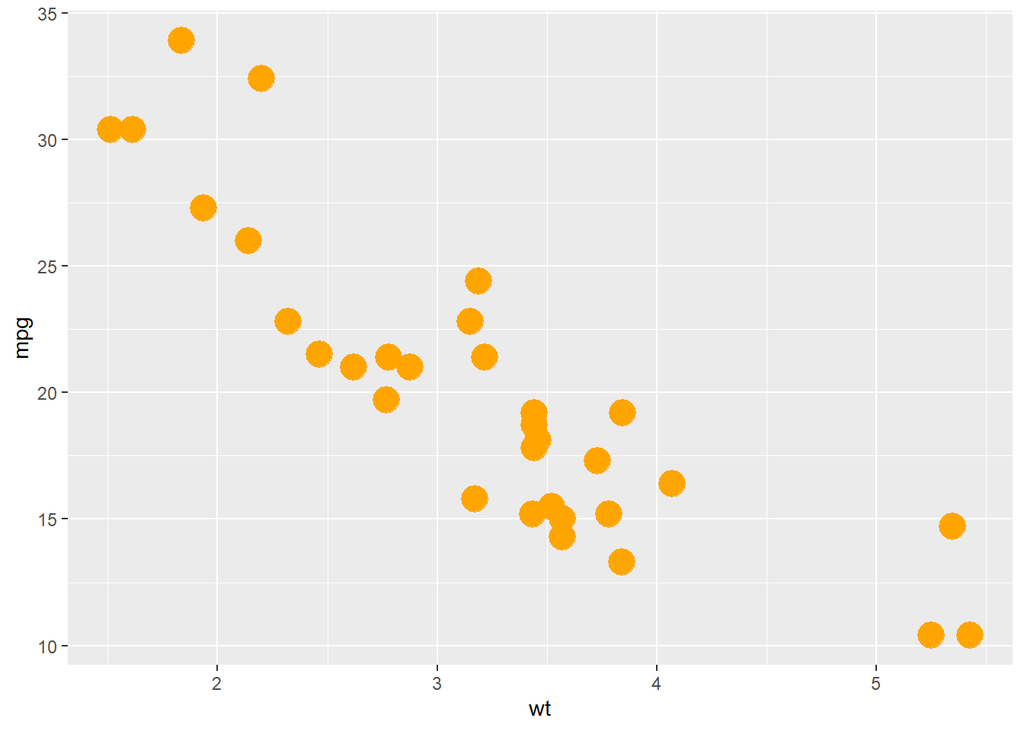

```r
p <- ggplot(data = mtcars, aes(wt, y=mpg))
p + geom_point(colour="orange",size=6)
```

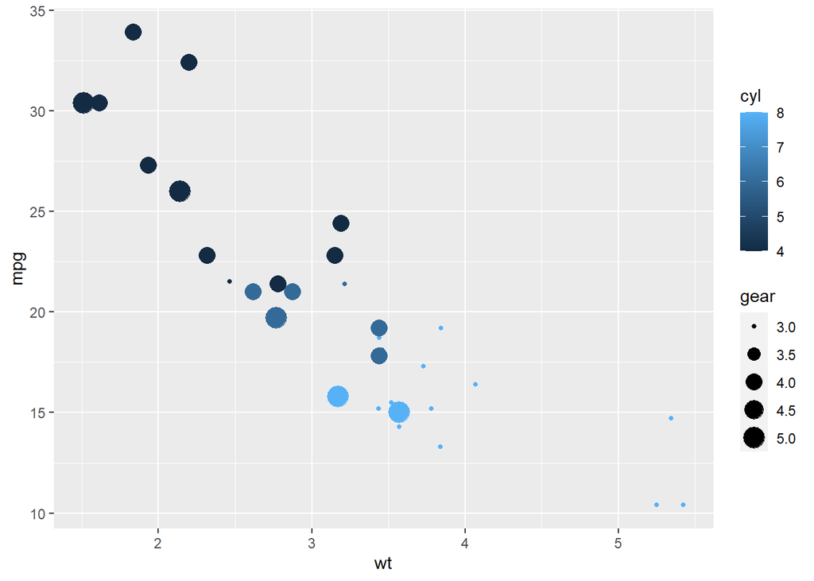

```r
p + geom_point(aes(colour=cyl, size=gear))
```

### 2.2.2 geom_bar() 막대 그래프

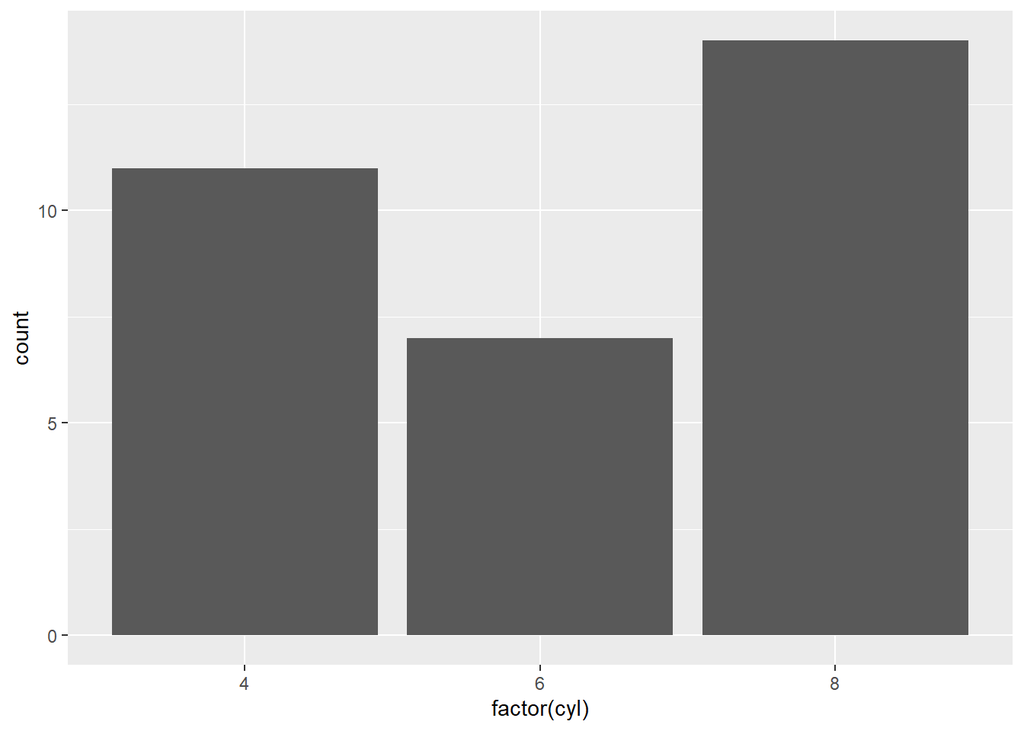

```r
p <- ggplot(mtcars, aes(factor(cyl)))
p + geom_bar()
```

* geom_bar를 aes함수로 꾸미기

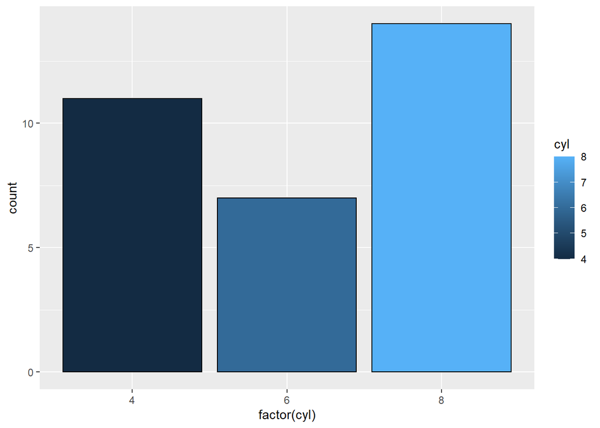

```r
p <- ggplot(mtcars, aes(factor(cyl)))
p + geom_bar(aes(fill=cyl),colour="black")
```

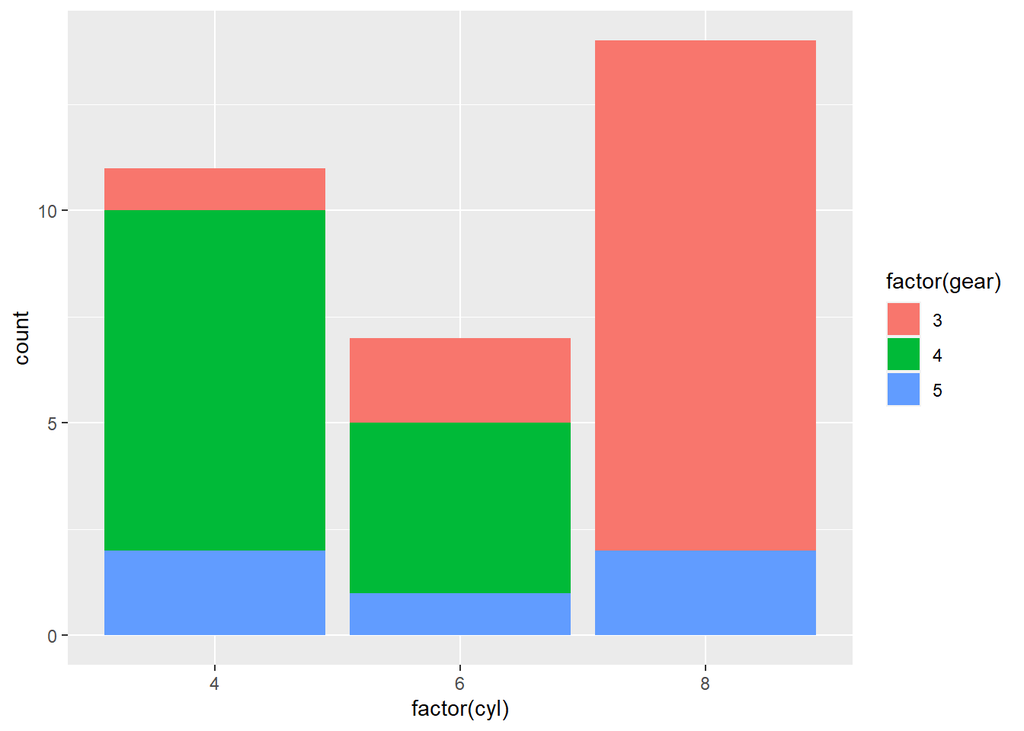

```r
p <- ggplot(mtcars, aes(factor(cyl)))
p+geom_bar(aes(fill=factor(gear)))
```

### 2.2.3. geom_boxplot() 박스플롯

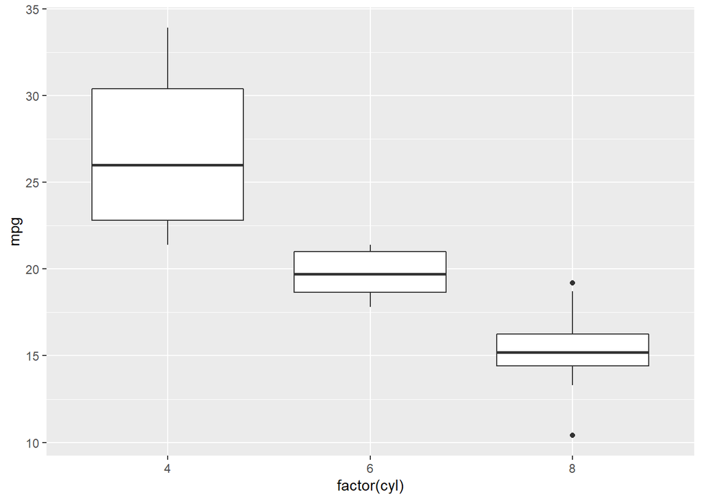

```r
p <- ggplot(mtcars, aes(factor(cyl),mpg)) #기본 박스플랏
p <- p + geom_boxplot()
p
```

- box-plot을 aes함수로 꾸미기

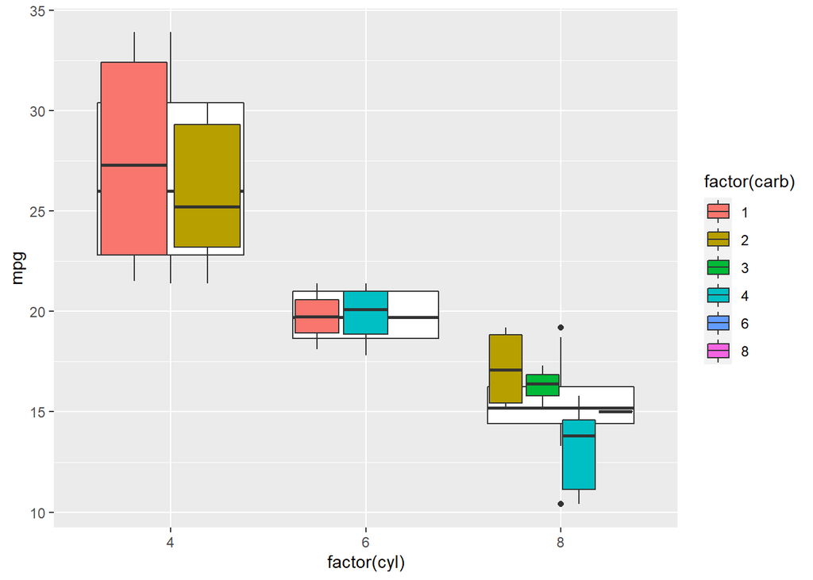

```r
p + geom_boxplot(aes(fill=factor(carb))) #박스 내부를 carb 팩터로 구분하여 표현
```

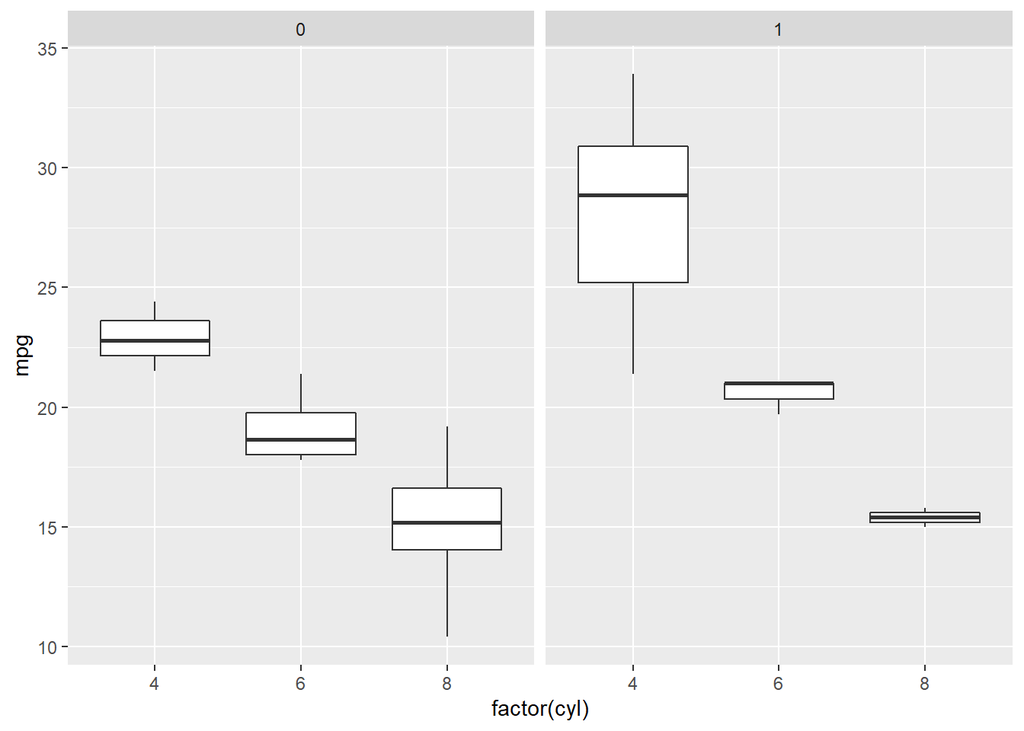

```r
p + facet_grid(~am) #am을 기준으로 facet 분리
```

### 2.2.4. geom_histogram() 히스토그램

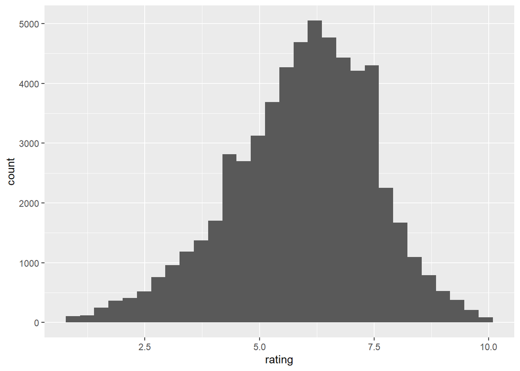

```r
# install.packages("ggplot2movies")
library(ggplot2movies)
p <- ggplot(movies,aes(rating))
p <- p+geom_histogram()
p
```

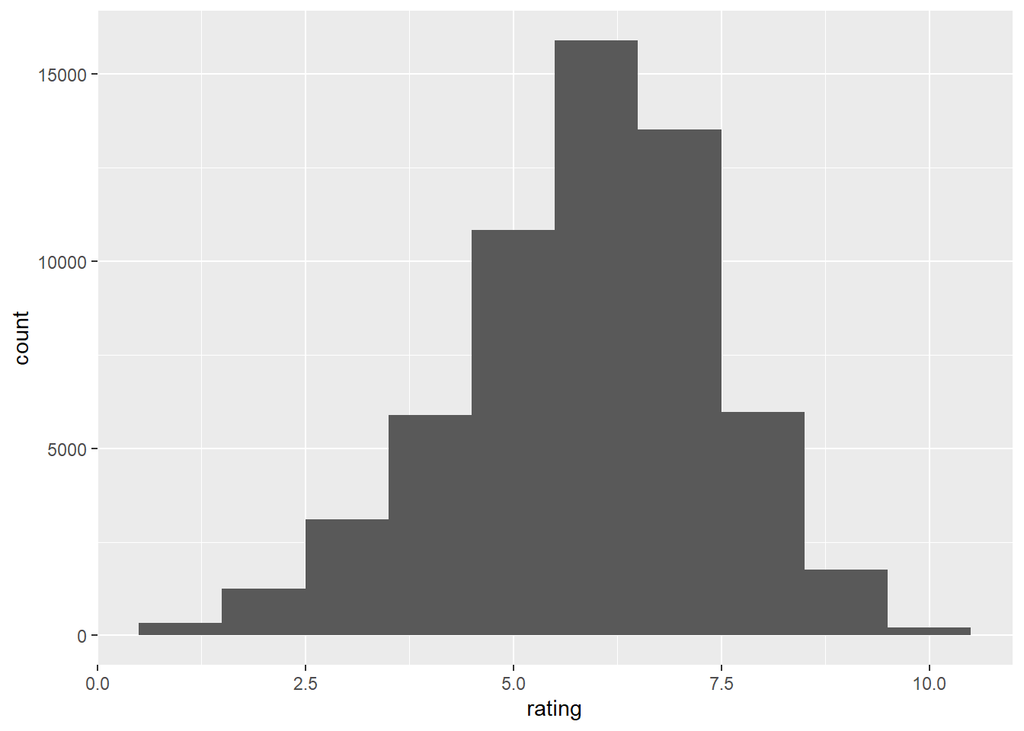

```r
# binwidth: histogram의 막대의 넓이 조절
p <- p+geom_histogram(binwidth=1)
p
```

*Histogram에 확률밀도곡선 표현

```r
head(movies)
```

| title | year | length | budget | rating | votes | r1 | r2 | r3 | r4 | r5 | r6 | r7 | r8 | r9 | r10 | mpaa | Action | Animation | Comedy | Drama | Documentary | Romance | Short |
| --- | --- | --- | --- | --- | --- | --- | --- | --- | --- | --- | --- | --- | --- | --- | --- | --- | --- | --- | --- | --- | --- | --- | --- |
| $ | 1971 | 121 | NA | 6.4 | 348 | 4.5 | 4.5 | 4.5 | 4.5 | 14.5 | 24.5 | 24.5 | 14.5 | 4.5 | 4.5 |  | 0 | 0 | 1 | 1 | 0 | 0 | 0 |
| $1000 a Touchdown | 1939 | 71 | NA | 6.0 | 20 | 0.0 | 14.5 | 4.5 | 24.5 | 14.5 | 14.5 | 14.5 | 4.5 | 4.5 | 14.5 |  | 0 | 0 | 1 | 0 | 0 | 0 | 0 |
| $21 a Day Once a Month | 1941 | 7 | NA | 8.2 | 5 | 0.0 | 0.0 | 0.0 | 0.0 | 0.0 | 24.5 | 0.0 | 44.5 | 24.5 | 24.5 |  | 0 | 1 | 0 | 0 | 0 | 0 | 1 |
| $40,000 | 1996 | 70 | NA | 8.2 | 6 | 14.5 | 0.0 | 0.0 | 0.0 | 0.0 | 0.0 | 0.0 | 0.0 | 34.5 | 45.5 |  | 0 | 0 | 1 | 0 | 0 | 0 | 0 |
| $50,000 Climax Show, The | 1975 | 71 | NA | 3.4 | 17 | 24.5 | 4.5 | 0.0 | 14.5 | 14.5 | 4.5 | 0.0 | 0.0 | 0.0 | 24.5 |  | 0 | 0 | 0 | 0 | 0 | 0 | 0 |
| $pent | 2000 | 91 | NA | 4.3 | 45 | 4.5 | 4.5 | 4.5 | 14.5 | 14.5 | 14.5 | 4.5 | 4.5 | 14.5 | 14.5 |  | 0 | 0 | 0 | 1 | 0 | 0 | 0 |

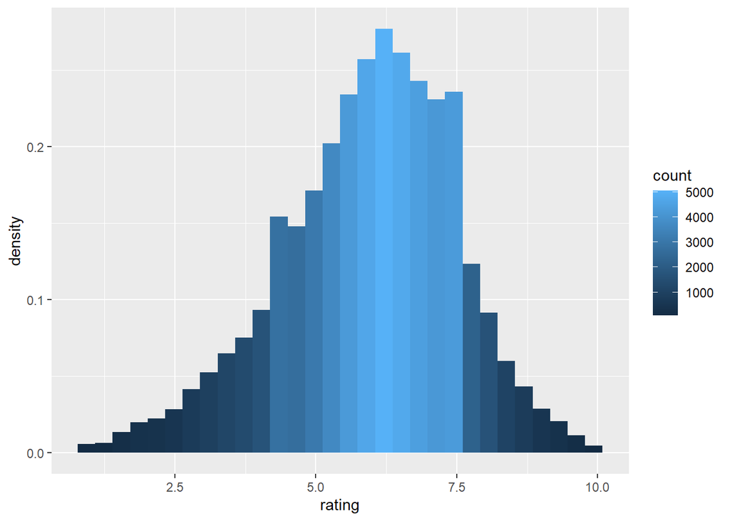

```r
p <- ggplot(movies,aes(rating))
p <- p + geom_histogram(aes(y=..density..,fill=..count..)) ; p#히스토그렘 그리기 =
```

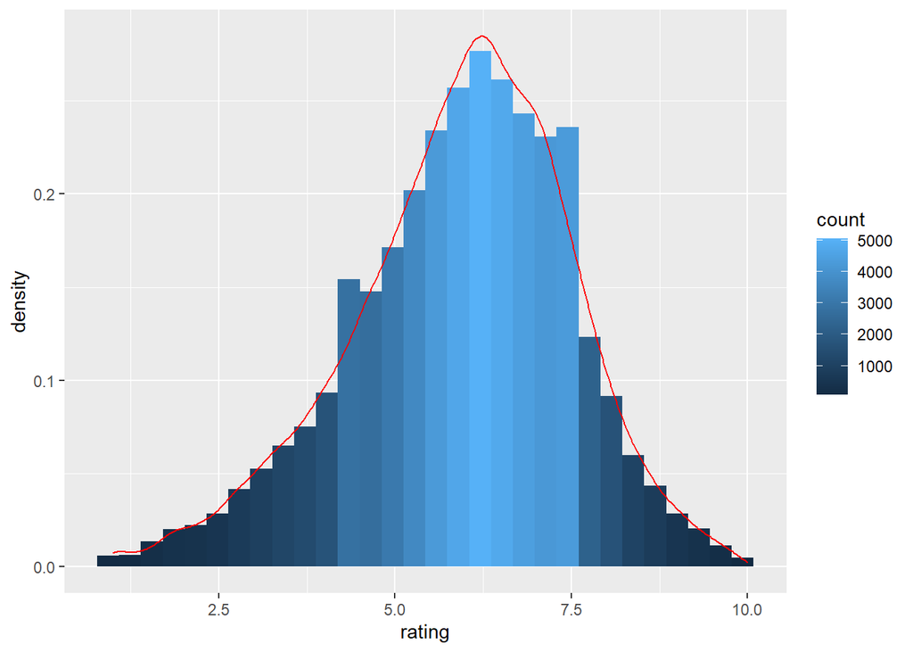

```r
p <- p + geom_density(colour="red") ; p#확률밀도곡선 그리기
```

```r
p <- p + scale_fill_gradient(low="white",high="#496ff5") ; p#그라데이션 추가
```

[figure not shown]

### 2.2.5. geom_density() 확률밀도곡선

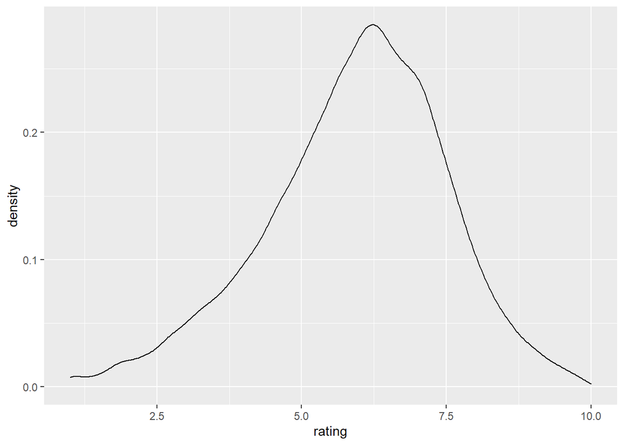

```r
p <- ggplot(movies,aes(rating))
p <- p +geom_density()
p
```

- 여러개의 확률밀도곡선 그리기
- aes(fill=factor(mpaa))인수로 mpaa를 분류한 rating의 확률밀도곡선 그리기

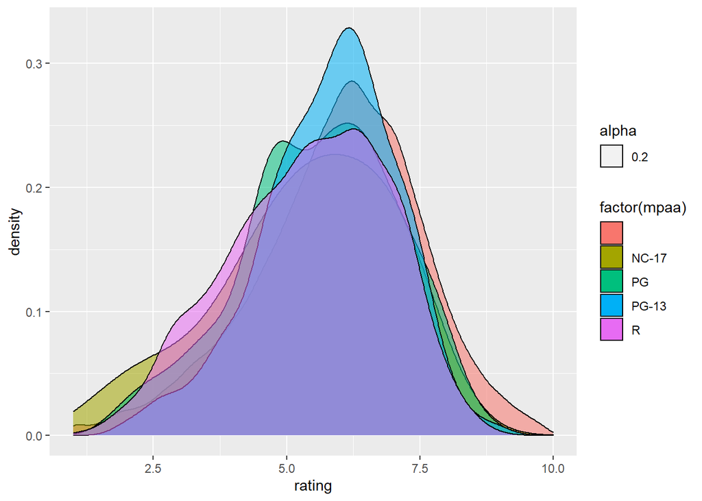

```r
p <- ggplot(movies,aes(rating))
p <- p + geom_density(aes(fill=factor(mpaa),alpha=0.2))
p
```

# 3.leaflet

- leaflet 패키지는 interactive한 그래프를 그릴 수 있는 패키지
- 구글맵과 오픈스트리트 맵을 이용하여 공간데이터를 시각화 함

```r
#install.packages(leaflet)
library(leaflet)
library(dplyr)
m = leaflet() %>% addTiles()
m = m %>% setView(127.0462, 37.2830, zoom =15) #아주대 경도위 위도 설정
m %>% addPopups(127.0462, 37.2830, 'Here is Ajou University!')
```

[interactive chart not shown]

## leaflet 예제

- addTiles()함수와 addAwesomeMarkers함수 사용
- 서울시 교통 돌발상황 조회 서비스 데이터 중 일부를 사용하여 지도에 표시하기

### 데이터로드 및 시각화

```r
traffic <- read.csv("traffic.csv", fileEncoding="utf-8")
range(traffic$start.pos.x) #돌발상황 시작점 경도
```

```
## [1]   0.0000 129.1827
```

```r
range(traffic$start.pos.y) #돌발상황 시작점 위도
```

```
## [1]  0.00000 37.69728
```

```r
traffic1 <- traffic[traffic$start.pos.x!=0 & traffic$start.pos.y!=0,] #na값 제거(0인값)

leaflet(traffic1) %>% addTiles() %>%
addAwesomeMarkers(~start.pos.x, ~start.pos.y)
```

[interactive chart not shown]

#### 출처 ###### 1. R을 활용한 데이터 시각화 - 유충현,홍석학 ###### 2.ggplot2 - 김성근 ###### 3.R라뷰 - 서진수

# PR11 연습문제

- 주어진 BGCON_CUST_DATA.csv 파일을 사용하여 다음을 해결하시오.
- BGCON_CUST_DATA.csv는 2016년 빅콘테스트에서 제공된 보험사기여부 데이터를 수정 가공한 것 입니다.
- 각 열 이름의 의미는 다음과 같습니다.
  - ID : 고객을 구분하는 고유번호
  - SIU : Y의 경우 보험사기자, N의 경우 일반고객
  - GENDER : 성별 1은 남성, 성별 2는 여성
  - AGE : 고객 연령
  - RESI_COST : 고객의 거줒 주택가격 추정값 (단위:만원)
  - FP_CA : (당사 FP로서의) Y:경력 있음, N:경력 없음
  - RGST : 최초 당사의 고객으로서의 등록 년월
  - CTPR : 고객의 거주 시/도
  - WEDD : Y :결혼함,N: 결혼 안함(계약 당시에는 결호하지 않았던 상태 포함)
  - CHLD : 고객의 자녀 수
  - DMND_AMT : 청구금액
  - PAYM_AMT : 지불금액

## 문제 1

- 거주지 가겨이 100000 이상인 고객에 한하여 다음을 생성하시오.

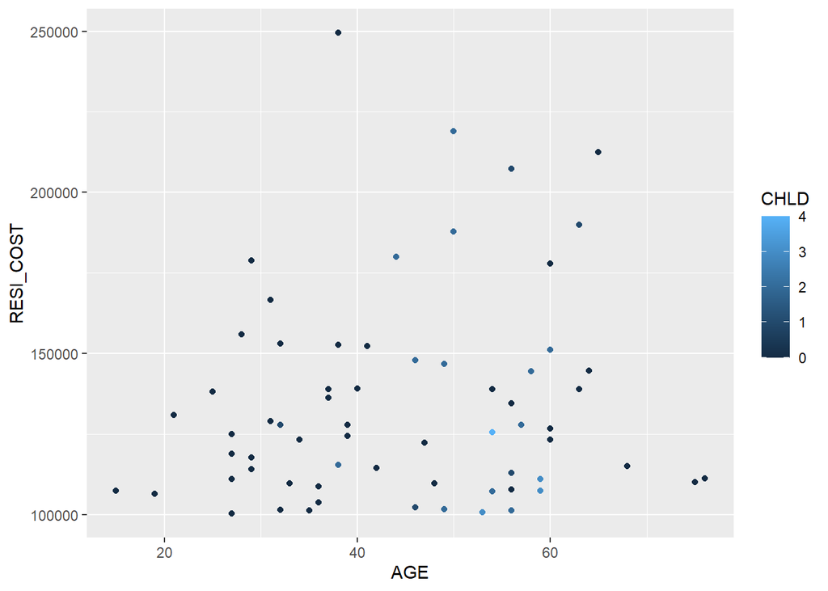

```r
setwd("C:\\Users\\JSW\\Desktop\\강의자료\\R프로그래밍\\R 실습 및 과제\\PR")
BC_cust<- read.csv("BGCON_CUST_DATA.csv")

BC_cust1 <- BC_cust[BC_cust$RESI_COST>100000,]

library(ggplot2)

p <- ggplot(data=BC_cust1,aes(x=AGE,y=RESI_COST,colour=CHLD))

p <- p + geom_point()

p
```

## 문제2

- 보험사기 고객에 대하여 다음을 생성하시오(성별에 따라 구분할 것)

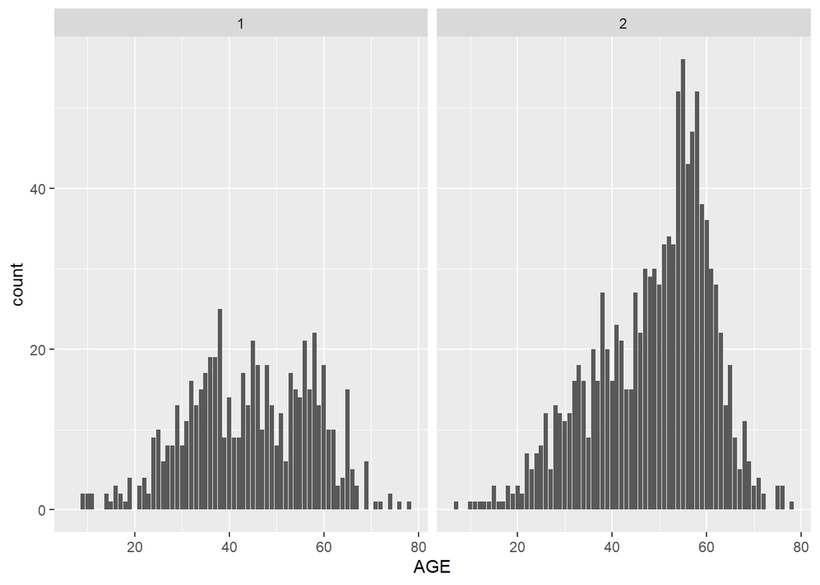

```r
BC_cust2 <- BC_cust[BC_cust$SIU=="Y",]

p <- ggplot(BC_cust2,aes(AGE))
p <- p + geom_bar()
p <- p + facet_grid(~GENDER) ; p
```

## 문제 3

- 보험사기 고객중 지불금액이 4000000 이상이고 14000000 이하인 고객에 대하여 다음을 생성하시오.

```r
BC_cust3 <- BC_cust2[BC_cust2$PAYM_AMT > 4000000 & BC_cust2$PAYM_AMT < 14000000,]

BC_cust3
```

|  | ID | SIU | GENDER | AGE | RESI_COST | FP_CA | RGST | CTPR | WEDD | CHLD | DMND_AMT | PAYM_AMT |
| --- | --- | --- | --- | --- | --- | --- | --- | --- | --- | --- | --- | --- |
| 23 | 6849 | Y | 2 | 65 | 3793 | Y | 199809 | 강원 | N | 0 | 4025000 | 4025000 |
| 209 | 21885 | Y | 1 | 33 | 14274 | N | 200405 | 강원 | Y | 1 | 4503397 | 4500000 |
| 318 | 11797 | Y | 1 | 55 | 3129 | N | 200306 | 강원 | N | 0 | 7798757 | 7780000 |
| 1564 | 2209 | Y | 2 | 44 | 15555 | N | 201312 | 경기 | Y | 0 | 5000000 | 5000000 |
| 3106 | 6692 | Y | 1 | 35 | 20972 | N | 201202 | 경기 | N | 0 | 5033301 | 5000000 |
| 3195 | 1258 | Y | 1 | 36 | 9745 | N | 200306 | 경기 | N | 0 | 10000000 | 10000000 |
| 3663 | 7430 | Y | 2 | 54 | 9504 | N | 200306 | 경기 | Y | 3 | 4187730 | 4187730 |
| 4209 | 19867 | Y | 1 | 27 | 8703 | N | 200705 | 경기 | N | 0 | 4258000 | 4258000 |
| 5289 | 8229 | Y | 2 | 58 | 26111 | N | 200102 | 경남 | Y | 2 | 10000000 | 10000000 |
| 5558 | 14946 | Y | 1 | 50 | 12083 | N | 200104 | 경남 | Y | 1 | 5940000 | 5940000 |

[output cut: 19 more lines]

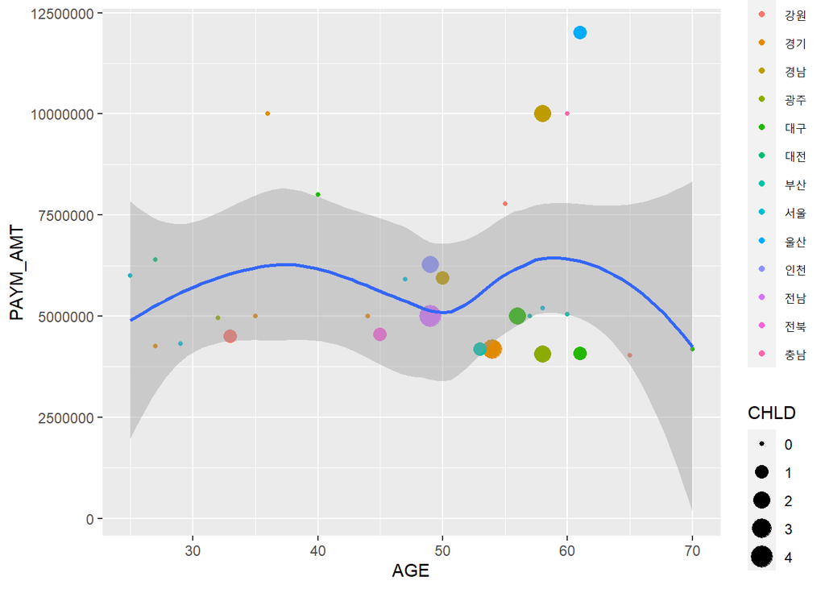

```r
p <- ggplot(data=BC_cust3,aes(x=AGE,y=PAYM_AMT))
p <- p + geom_point(aes(colour=CTPR,size=CHLD))

p <- p+geom_smooth(method="loess")
p
```

## 문제 4

- 당사 FP로서의 경력이 있는 고객에 대하여 다음을 생성하시오.

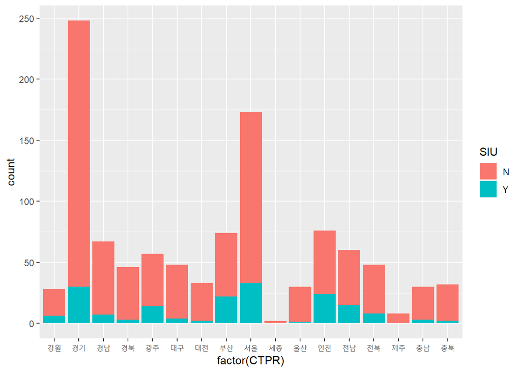

```r
BC_cust4 <- BC_cust[BC_cust$FP_CA=="Y",]
p <- ggplot(BC_cust4,aes(factor(CTPR)))
p + geom_bar(aes(fill=SIU))
```

## 문제 5

- 보험 사기고객이 아닌 고객에 대하여 다음을 생성하시오

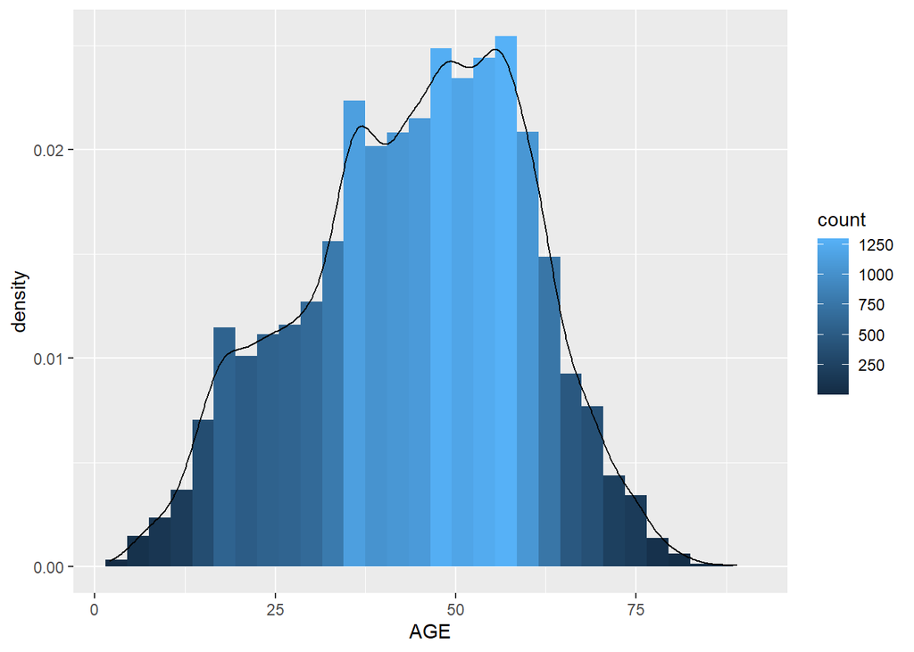

```r
BC_cust5 <- BC_cust[BC_cust$SIU=="N",]

p <- ggplot(BC_cust5,aes(AGE))
p <- p + geom_histogram(aes(y=..density..,fill=..count..))
p <- p + geom_density(colour="black")
p
```

## 문제6

- 각 시도별 보험사기 고객 비율(per)를 구하여 다음을 생성하시오.

```r
library(leaflet)
library(dplyr)

setwd("C:\\Users\\JSW\\Desktop\\강의자료\\R프로그래밍\\R 실습 및 과제\\PR")

BC_cust<- read.csv("BGCON_CUST_DATA.csv") #읽어오기

BC_cust1 <- select(BC_cust,CTPR,SIU) # 지역과 보험사기여부만으로 데이터프레임을 재구성합니다




ratiofunc <- function(a,b) {  #각 시도별 보험사기 백분율을 계산하기위한 함수를 정의합니다.(a=데이터셋, b=지역명 )
  ratio1 = NULL
  ratio1.1 = NULL
  ratio1 <- select(subset(a,CTPR==b),SIU)
  ratio1.1 <- select(subset(ratio1,SIU=="Y"),SIU)
  c <- length(ratio1.1$SIU) / length(ratio1$SIU)
  return(c)

}


Region <-  c("강원","경기","경남","경북","광주","대구","대전","부산","서울","세종","울산","인천","전남","전북","제주","충남","충북") #지역명 변수 선언

ratioGroup <- 0     #앞서 정의했던 함수를 반복문으로 각 시도별 보험사기 백분율을 한번에 구해줍니다
for (i in 1:length(Region)){
  ratioGroup[i] <- ratiofunc(BC_cust1,Region[i])
}

FF <- data.frame(Region,ratioGroup)   #보험사기 백분율과 앞서 선언한 지역명변수를 FF 데이터프레임으로 구성합니다.
FF <-FF[order(FF$ratioGroup),] #보험사기백분율의 크기순으로 정렬합니다.
rownames(FF) <- NULL   #재정렬한 순서에 맞춰 행이름을 재설정해줍니다


PER<-0 #총 17지역이므로 17중 순위에맞게 백분위를 계산해줍니다 PER변수에 백분위가 차례로 들어갈것입니다.
totalRG <- for (i in 1:17){
  PER[i] <- i/17 *100
}

FF<- data.frame(FF,PER) #보험사기백분율 FF데이터프레임과 PER함수를 묶어줍니다

#-- leaflet 활용 시작------------------/

pal3<-colorBin(palette="YlOrRd", domain=c(0,100), bins = 8, pretty=F, alpha = T) #0~100을 8클래스로 나눈 파레트를 만듭니다.
pal <-colorFactor(palette = "YlOrRd",domain=NULL)
#-----
class <- c("c1","c1","c2","c2","c3",'c3',"c4",'c4','c5','c5','c6','c6','c7','c7','c8','c8','c8') #기존 데이터프레임의 백분위를 범례의 구간별로 할당할 벡터 class를 선언해줍니다
# C1: 0 - 15
# C2: 15- 25
# C3: 25 - 38
# C4: 38 - 50
# C5: 50 - 62
# C6: 62 - 75
# C7: 75 - 88
# C8: 88 - 100


FF<- data.frame(FF,class) #FF와 class를 병합합니다
#--------------------------------------
L.L <- read.csv("KOR_LAT_LON.csv") #위.경도 데이터를 불러옵니다

colnames(L.L)<- c("Region","Lat","Lon") #위경도데이터의 열이름을 바꿔줍니다



GG<-NULL
HH<-NULL

for (i in 1:length(FF$Region)){  #앞서 FF에서 범죄백분율 크기 기준으로 정렬되었던 지역명의 순서대로 맞추어서 위경도데이터를 재구성합니다.
  GG<- L.L[L.L$Region==FF$Region[i],]
  H <- GG[,2:3]
  HH<-bind_rows(HH,H)
}

FF <- bind_cols(FF,HH)  #위의 반복문으로 FF순서에맞춰 재구성된 HH를 FF에 합쳐줍니다
#--------------------------------------
m=0
m = leaflet() %>% addTiles() %>%   # leaflet 활용부분입니다.
  setView(126.9860,37.54100,zoom=7) #snapshot에서 보여줄 경도와 위도 확대정도를 설정합니다

m = m %>% addLegend(pal = pal3,  #addLegend는 범례생성함수입니다.
                    values  = FF$ratioGroup,
                    position = "bottomright",
                    title = "ratio",
                    labFormat = labelFormat(suffix="%",between="%&ndash;")) #맨끝에 and '-'뒤에 %를 붙여주도록 설정합니다
m %>% addCircleMarkers(data=FF,radius=5,color= ~pal(class),)   #문제의 예시에 맞게 크기를 radius로 조절하고 FF 데이터프레임에 맞춘 circles를 찍어줍니다
```

```
## Assuming "Lon" and "Lat" are longitude and latitude, respectively
```

[interactive chart not shown]